# 统计（机器）学习 Homework-6 报告：力扣题目难度预测

林子开 21307110161

2023年11月12日

# 一、导入数据与数据清洗

读入数据，创建EASY变量，并对某些列进行重新命名（不然之后在随机森林部分会报错）。

```r
# 读入数据
library(readr)
data <- read_csv("D:/大三上学习资料/统计（机器）学习/hw6/lc_data.csv")
data = as.data.frame(data)

# 创建EASY变量
data$EASY = 1*(data$difficulty=='EASY')

# 对某些列重新命名，否则之后做随机森林会出问题
newNames <- c( "linked_list","math","hash_table","string","binary_search",
"divide_and_conquer", "dynamic_programming","greedy","two_pointers","sorting",
"backtracking","heap_priority_queue", "simulation","depth_first_search",
"binary_tree","breadth_first_search","union_find","graph",
"geometry","database","topological_sort","prefix_sum","shortest_path" )
colnames(data)[21:43] <- newNames
```

# 二、对分类变量设置基准组

将EASY, quesclass, example的基准组分别设置为0、题库、1

```r
data$EASY = factor(data$EASY)
data$EASY = relevel(data$EASY,'0')
data$quesClass = factor(data$quesClass)
data$quesClass = relevel(data$quesClass,'题库')
data$example = factor(data$example,levels = c(1,2,3,4,5,6))
data$difficulty = factor(data$difficulty,levels=c('EASY','MEDIUM','HARD'))
data$ifcom = factor(data$ifcom)
```

分类标签数量，我们只关心无或有，因此按照0/1重新赋值

```r
data$Algorithms = data$Algorithms>0
data$Common.Data.Structures = data$Common.Data.Structures>0
data$Advanced.Data.Structures = data$Advanced.Data.Structures>0
data$Techniques = data$Techniques>0
data$Math = data$Math>0
data$Other = data$Other>0
```

# 三、描述性分析

## 三种不同题目难度占比分布直方图

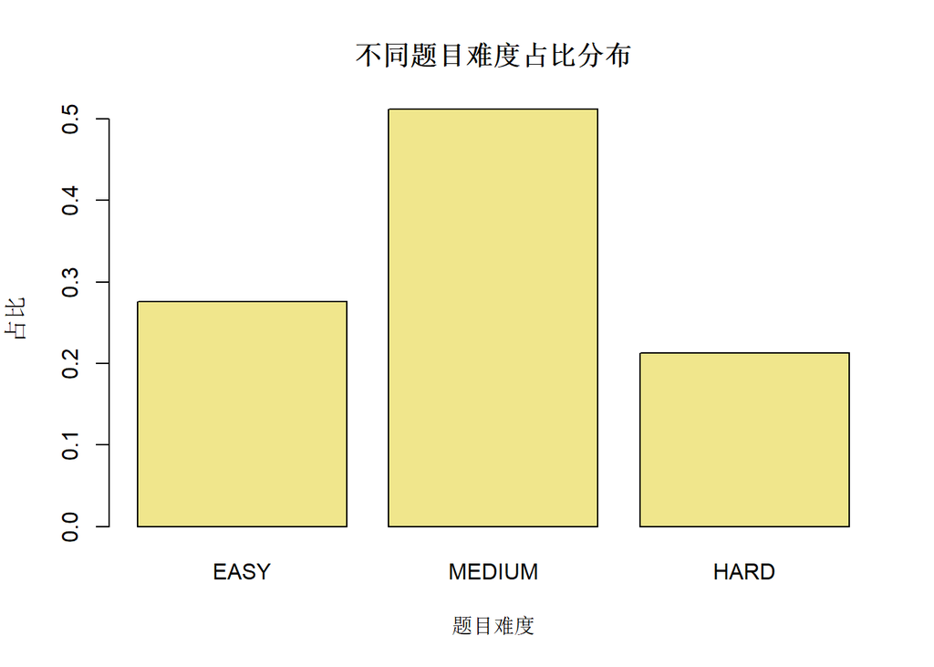

```r
difficult.table = table(data$difficulty)/nrow(data)
barplot(difficult.table,main='不同题目难度占比分布',xlab = '题目难度',ylab = '占比',col = 'khaki')
```

从直方图可以看出，中等难度的题目数量最多，大约占50%，其次是简单题，大约占30%，最后是困难题，大约占20%。

## 不同题目难度的题目要求文本长度箱线图

绘制不同题目难度的题目要求文本长度箱线图如下所示

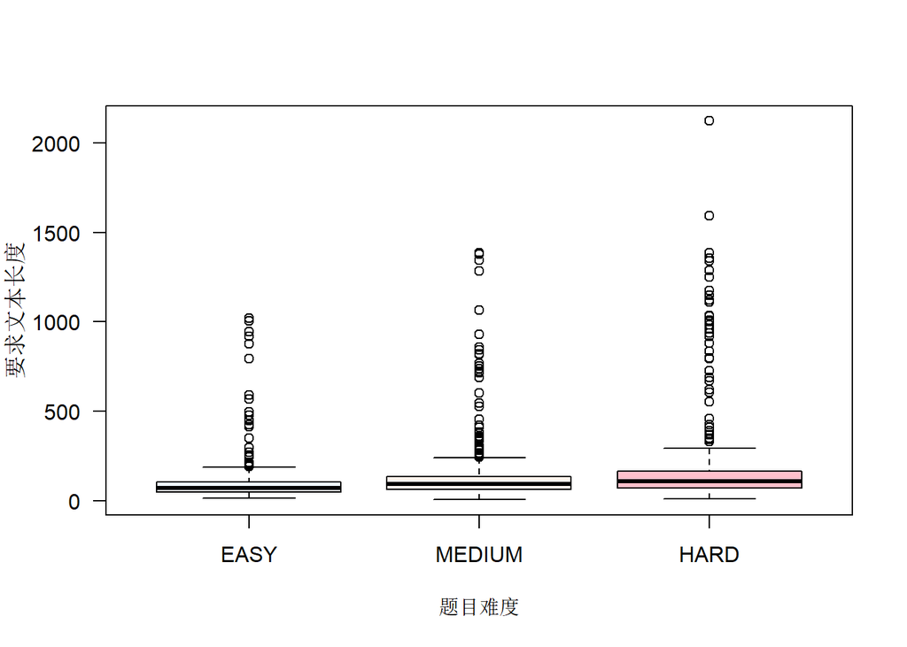

```r
boxplot(requireLen~difficulty,data=data,col=c('aliceblue','seashell','pink'),xlab='题目难度',ylab='要求文本长度',cex.lab=1,cex.axis=1,las=1)
```

由于原始数据右偏，直接画箱线图效果不好，于是对文本长度**先取对数后画箱线图**，如下图所示

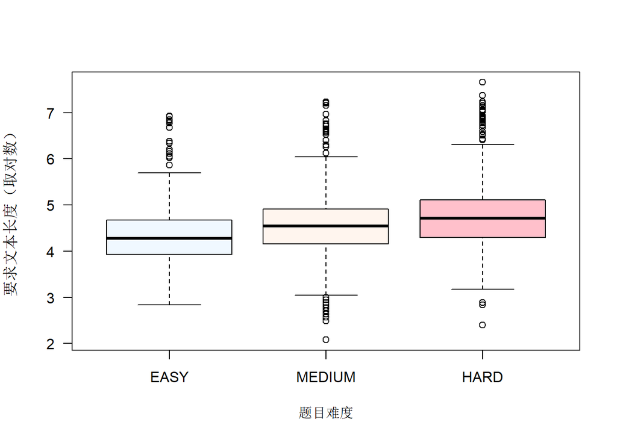

```r
boxplot(log(requireLen)~difficulty,data=data,col=c('aliceblue','seashell','pink'),xlab='题目难度',ylab='要求文本长度（取对数）',cex.lab=1,cex.axis=1,las=1)
```

可以看出，随着题目难度的增加，题目文本的长度也就越大，提干也就越复杂。

## 不同题目难度的题目给出的示例数量占比柱状图

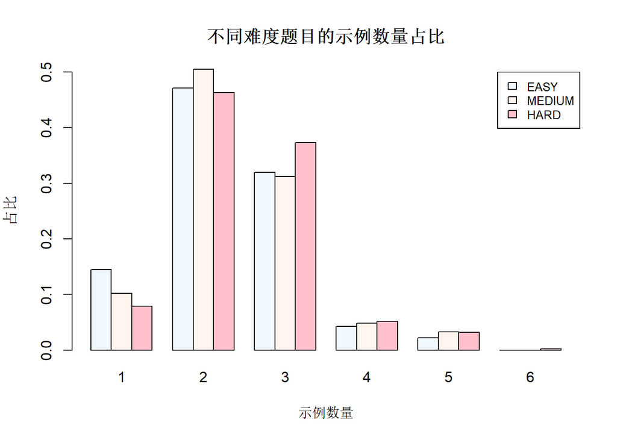

```r
subset.EASY = subset(data,difficulty=='EASY')
subset.MEDIUM = subset(data,difficulty=='MEDIUM')
subset.HARD = subset(data,difficulty=='HARD')
difficult.example.table = rbind(table(subset.EASY$example)/nrow(subset.EASY),table(subset.MEDIUM$example)/nrow(subset.MEDIUM),table(subset.HARD$example)/nrow(subset.HARD))
rownames(difficult.example.table) = c('EASY','MEDIUM','HARD')
barplot(difficult.example.table, beside = T, col = c('aliceblue','seashell','pink'), main = "不同难度题目的示例数量占比", xlab = '示例数量',ylab='占比',ylim = c(0,0.5))
legend("topright", legend = rownames(difficult.example.table), fill =  c('aliceblue','seashell','pink'), cex = 0.8)
```

可以看出，简单题给出的示例数量相对较少，而困难题给出的示例数量相对较多，而中等题介于二者之间。不过该趋势不是特别明显，大部分的题目给出的示例数量都在2~3个。

## 不同公司的题目数量柱状图

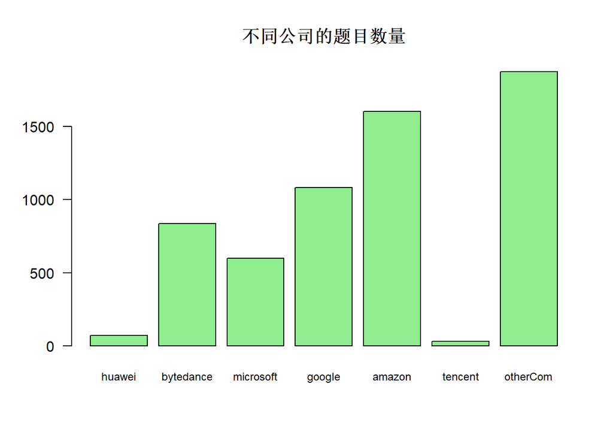

```r
companies = c("huawei","bytedance","microsoft","google","amazon","tencent","otherCom")
company.problem.table = numeric(7)
for(i in 1:7){
  company = companies[i]
  company.problem.table[i] = sum(data[company])
}
barplot(company.problem.table,names.arg=companies,col='lightgreen',las=1,main='不同公司的题目数量',cex.names = 0.75)
```

可以看出，其他公司的题目数量最多。在此之外，亚马逊公司的题目数量最多，其次是谷歌、字节跳动、微软、华为，最后是腾讯。

## 根据不同的分类标签，绘制简单题所占的比例直方图

```r
label = c("Algorithms","Common.Data.Structures","Advanced.Data.Structures","Techniques","Math","Other")
label.easy.table = numeric(6)
for(i in 1:6){
  s = subset(data,data[label[i]]!=0)
  print(label[i])
  label.easy.table[i] = nrow(subset(s,EASY==1))/nrow(s)
}
label.easy.table = as.data.frame(label.easy.table)
```

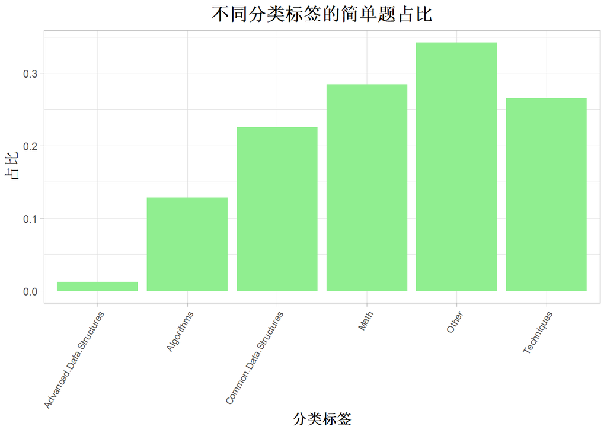

```r
perf = ggplot(data=label.easy.table,aes(x=label, y=label.easy.table))+
  geom_bar(stat='identity',fill="lightgreen")+ylab('占比')+xlab('分类标签')+theme_light()+
  theme(axis.text.x = element_text(angle=60, hjust=1,size=8),
        plot.title = element_text(color="black", size=15, face="bold",hjust=0.5),
        axis.title.x = element_text(color="black", size=12, face="bold"),
        axis.title.y = element_text(color="black", size=12, face="bold"))+
        ggtitle('不同分类标签的简单题占比')
perf
```

由于我们只关心是否具有该分类标签，而不在乎分类标签个数，因此我们只根据是否具有标签进行分类统计。从图中可以看出，Other类的标签下的简单题最多，接下来依次是Math类、Techniques类、Common-Data-Structures类、Algorithms类。最少的是Advanced-Data-Structures类，几乎没有简单题。

# 四、建模数据预处理

## 重采样

使用自定义的方式，进行重采样

```r
set.seed(2023)
subset.NOT.EASY = subset(data,EASY==0)
subset.EASY = subset(data,EASY==1)
nsample = sample(x = dim(subset.NOT.EASY)[1],
                 size = dim(subset.NOT.EASY)[1]*0.380304, replace = F)
subset.NOT.EASY.sample = subset.NOT.EASY[nsample, ]
data.balanced = rbind(subset.EASY,subset.NOT.EASY.sample)
```

重采样后的数据较为平衡，如下所示：

```r
table(data.balanced$EASY)
```

```
##
##   0   1
## 726 726
```

## 分割

设置随机数种子

```r
set.seed(2023)
```

有一些属性在接下来的训练中不再使用，包括 difficulty（等效于EASY，不应该作为自变量），Fundamentals（该变量含义未知），require（文本类变量，价值密度低），tips（文本类变量，价值密度低），将这些变量先删除:

```r
data.balanced = data.balanced[,-c(6,45,46,47)]
```

然后按照7:3的比例划分训练集和测试集：

```r
nsample = sample(x = dim(data.balanced)[1], size = dim(data.balanced)[1]*0.7, replace = F)
## 重新划分训练集和测试集
data.train = data.balanced[nsample, ]
data.test = data.balanced[-nsample, ]
```

# 五、建模

## CART决策树

建立CART决策树如下

```r
result.rp = rpart(EASY~.,data = data.train,method='class')
```

变量的相对重要性排序如下

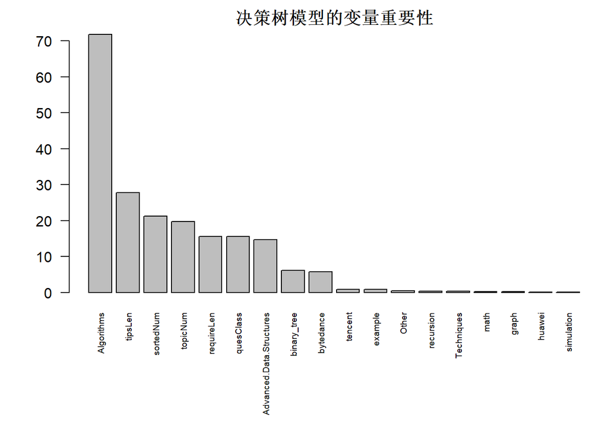

```r
importance = result.rp$variable.importance
opar <- par(mfrow=c(1,1),mar=c(8, 4, 2, 0.5))
barplot(importance,las=2,cex.names = 0.6,main='决策树模型的变量重要性')
```

可以看出Algorithms,tipsLen,sortedNum,topicNum,requireLen,quesClass,Advanced-Date-Structures这几个变量是相对重要的变量。

决策树结果可视化：

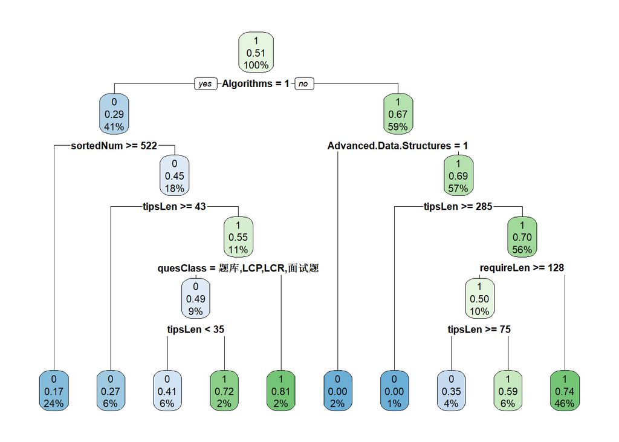

```r
rpart.plot(result.rp,type=2)
```

**解读**：决策树首先根据标签是否为Algorithms将样本分为两类， 对于标签为Algorithms的样本，只有29%是简单题，对于标签不包含Algorithms的样本，有67%是简单题，两个子集的简单题比例差别非常显著，这也反映出Algorithms是非常重要的指标。对于带有Algorithm标签的子集，则继续根据题库编号sortedNum等指标进一步分类。对于不带有Algorithm标签的，则继续根据Advanced-Data-Structures等指标进一步分类。

## 随机森林

建立随机森林模型如下，其中，经过测试，将参数ntree（多少棵树）设置为1000能够得到比较好的对测试集的预测结果。

```r
result.rf <- randomForest(EASY~., data = data.train, importance=TRUE,type='classification',ntree=1000)
```

变量的重要性排序和变量特征重要性图如下：

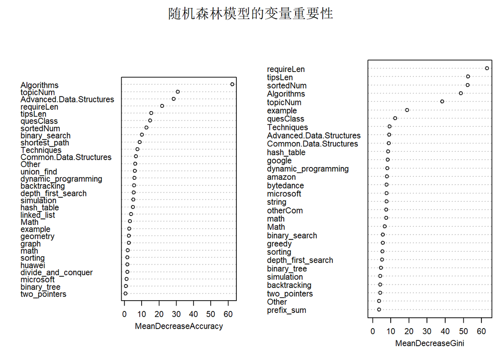

```r
opar <- par(mfrow=c(1,1),mar=c(8, 4, 2, 0.5))
varImpPlot(result.rf,main='随机森林模型的变量重要性',cex=0.7)
```

**解读**：上图提供了两种衡量变量重要性的标准。第一种是将变量进行随机扰动，导致预测准确率下降越多的变量则越重要。第二种则是基于基尼系数的下降进行衡量。基于第一种标准，Algorithms, Advanced-Data-Structures, topicNum, requireLen, tipsLen是比较重要的变量。基于第二个标准，requireLen, tipsLen, sortedNum, Algorithms, topicNum是比较重要的变量。综合两个指标，可以认为Algorithms, requireLen, topicNum, tipsLen是比较重要的变量。

## adaboost

建立adaboost模型如下，其中，经过测试，将参数mfinal（迭代轮次）设置为100能够得到比较好的对测试集的预测效果。

```r
result.adaboost <- boosting(EASY~., data=data.train, boos=F,mfinal = 100)
```

变量重要性如下：

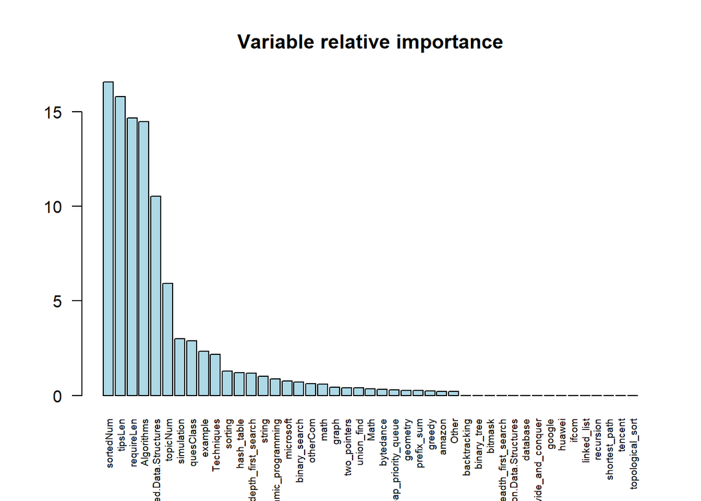

```r
importanceplot(result.adaboost,las=2,cex.name=0.6)
```

**解读**：由图可知sortedNum, tipsLen, requireLen, Algorithms, advaced-Data-Strutures, topicNum等是比较重要的变量，这与另外两个模型给出的较为重要的变量是基本一致的。

## 模型比较

使用以上三个模型的建模结果，对测试集数据进行预测

```r
pred.rp = predict(result.rp, data.test,type='prob')
pred.rf = predict(result.rf,data.test,type='prob')
pred.adaboost = predict(result.adaboost,data.test,type='prob')
```

绘制ROC曲线并展示AUC的值

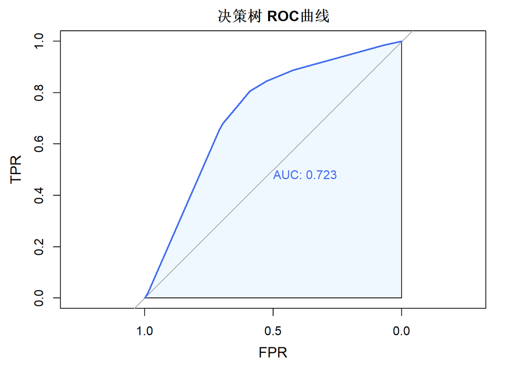

```r
opar <- par(mfrow=c(1,1))
plot.roc(data.test$EASY, pred.rp[,2],
         col = "royalblue2", print.auc=TRUE,
         auc.polygon=TRUE, auc.polygon.col="aliceblue",
         xlab = "FPR",ylab = "TPR", main = "决策树 ROC曲线",cex.lab=1.2)
```

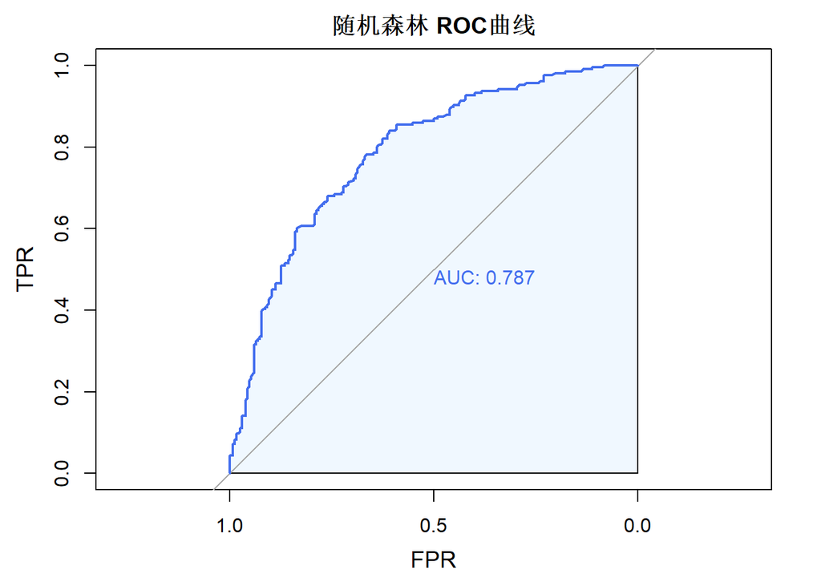

```r
plot.roc(data.test$EASY, pred.rf[,2],
         col = "royalblue2", print.auc=TRUE,
         auc.polygon=TRUE, auc.polygon.col="aliceblue",
         xlab = "FPR",ylab = "TPR", main = "随机森林 ROC曲线",cex.lab=1.2)
```

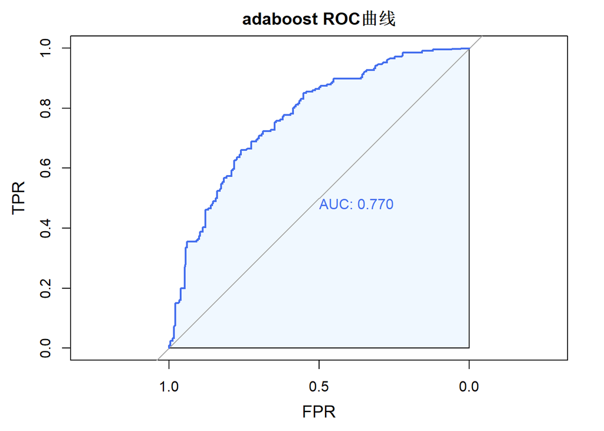

```r
plot.roc(data.test$EASY, pred.adaboost$prob[,2],
         col = "royalblue2", print.auc=TRUE,
         auc.polygon=TRUE, auc.polygon.col="aliceblue",
         xlab = "FPR",ylab = "TPR", main = "adaboost ROC曲线",cex.lab=1.2)
```

**解读**：对比三个模型的AUC值，可以发现预测精度：随机森林>adaboost>决策树，随机森林的预测精度最高。